# Corona project exploration (Draft Verion 0.2)

Zehui Bai

# Data Exploration

## Fragesetllung

Question 4/3: Wurden Sie gegen Corona geimpft? (ImpfZust)

## Selection of variables

Following variable are selected from the questionares:

- Perception of disease risk: 4/1; 4/2 (code)
  - Question 4/1: Kennen Sie Personen, die an Corona erkrankt sind? (PersoKenn)
  - Question 4/2: Hatte mindestens eine dieser Personen einen schweren Krankheitsverlauf? (KennErkr)
- Attitude towards vaccination (ImpGrund):
  - Question 4/16: Warum haben/ wollen Sie sich gegen Corona impfen lassen?
    - ImpGrund[beruf] Ich habe/ möchte mich aus beruflichen Gründen impfen lassen
    - ImpGrund[risiko] Ich möchte das Risiko einer Corona-Infektion verringern
    - ImpGrund[norm] Ich möchte schnell zum normalen Leben zurückkehren
    - ImpGrund[gesfam] Ich möchte die Gesundheit meiner Familie schützen
    - ImpGrund[sozum] Ich werde/ wurde von meinem sozialen Umfeld angetrieben
    - ImpGrund[gesell] Ich bin der Meinung, dass die Impfung einen wichtigen gesellschaftlichen Beitrag darstellt
    - ImpGrund[geswesent] Ich bin der Meinung, dass die Impfung einen wichtigen gesellschaftlichen Beitrag darstellt
- One’s own health status:
  - Question 2/2: Wie schätzen Sie Ihren allgemeinen körperlichen Gesundheitszustand im Durchschnitt über die letzten sechs Monate ein? (GesuZuK)
  - Question 2/3: Wie schätzen Sie Ihren allgemeinen psychischen Gesundheitszustand im Durchschnitt über die letzten sechs Monate ein? (GesuZuPsy)
  - Question 2/4: Welche der folgenden Impfungen haben Sie bereits erhalten?
    - Anam[HepB] Hepatitis B
    - Anam[Fern] Impfungen für Fernreisen (wie z.B. Japanische Enzephalitis, Gelbfieber, Typhus, Tollwut)
    - Anam[Inf] Influenza (mind. 1mal)
    - Anam[Mas] Masern
    - Anam[Mum] Mumps
    - Anam[Roet] Röteln
    - Anam[Pol] Polio (Kinderlähmung)
    - Anam[Nicht] Ich bin mir über meinen Impfstatus nicht sicher
    - Anam[Keine] Ich habe keine der hier aufgelisteten Impfungen erhalten
- Socio-demographic data:
  - Question 1/1: Bitte geben Sie Ihr Alter in Jahren an (Age)
  - Question 2/1: Welchem Geschlecht fühlen Sie sich zugehörig (Sex)
- Socio-economic status
  - Question 8/1: Was ist Ihr höchster Schulabschluss (Schulab)
  - Question 8/2: Was ist Ihr höchster beruflicher Abschluss? (BerufAb)
  - Question 8/3: Wie ist Ihr aktuelles Beschäftigungsverhältnis?
  - Question 8/4: Sind/ Waren Sie beruflich im Gesundheitswesen tätig? (TaetGes)
  - Question 8/5: In welchem Bereich sind/ waren Sie tätig? (TaetGesBer)
- Access to health information
  - Question 6/5: Wie oft informieren Sie sich bewusst über Corona? (ZeitInfo)
- Trust in government
  - Question 5/8: Wie zufrieden sind Sie mit der Arbeit der folgenden Einrichtungen während der Corona-Pandemie (in score transform)
- Compliance with health professionals
  - Question 5/4: Wie schätzen Sie die Qualität der Behandlung dieses Arztes/dieser Ärztin im Allgemeinen ein? (zapaQualBe)
  - Question 5/5: Werden/Wurden Sie durch einen Arzt/eine Ärztin über die Corona Impfungen aufgeklärt? (zapaImpf)
  - Question 5/6: Haben sie aktiv nach einer Aufklärung gefragt? (AufklAkt)
  - Question 5/7: Waren Sie zufrieden mit der Aufklärung über die Impfung (ZufriedAufk)
- Internet and social media (convert the variable)
  - Question 6/4: Bitte geben Sie an, wie oft Sie mit den folgenden Personengruppen über Corona sprechen. (**not find**)
- Additional analysis
  - Question 4/5: Wie viele Corona-Impfungen haben Sie bis jetzt erhalten? (ImpDos)
  - Question 9/5: Wie viele Personen leben in Ihrem Haushalt (Sie mit eingeschlossen)? (PersHaus)
  - Question 6/2: Bitte geben Sie an, welche der nachfolgenden Informationsquellen Sie bei der Suche nach allgemeinen Informationen nutzen und wie häufig.
  - Question 6/4: Bitte geben Sie an, wie oft Sie mit den folgenden Personengruppen über Corona sprechen. (Face2Face[Fam],Face2Face[Fachpers])
  - Question 9/6: Wie hoch ist Ihr monatliches Nettoeinkommen? (Eink)

## Variable convertion

For the Question “Question 4/16: Warum haben/ wollen Sie sich gegen Corona impfen lassen?”, the 7 sub questions will be regarded as seperate variables to explore the effects of different reason for vaccination. + ImpGrund[beruf] Ich habe/ möchte mich aus beruflichen Gründen impfen lassen + ImpGrund[risiko] Ich möchte das Risiko einer Corona-Infektion verringern + ImpGrund[norm] Ich möchte schnell zum normalen Leben zurückkehren + ImpGrund[gesfam] Ich möchte die Gesundheit meiner Familie schützen + ImpGrund[sozum] Ich werde/ wurde von meinem sozialen Umfeld angetrieben + ImpGrund[gesell] Ich bin der Meinung, dass die Impfung einen wichtigen gesellschaftlichen Beitrag darstellt + ImpGrund[geswesent] Ich bin der Meinung, dass die Impfung einen wichtigen gesellschaftlichen Beitrag darstellt

For the Question “Question 2/4: Welche der folgenden Impfungen haben Sie bereits erhalten?”, this Question will be converted to “Haben Sie andere Impfstoffe erhalten?” (ImpfHistory) If the participant has received any following vaccines (Check the following vaccine options), the answer of above question shoulb be “Ja”. * Hepatitis B * Impfungen für Fernreisen (wie z.B. Japanische Enzephalitis, Gelbfieber, Typhus, Tollwut) * Influenza (mind. 1mal) * Masern * Mumps * Röteln * Polio (Kinderlähmung) Otherwise, the check of following two options will conclude “Nein” as answer. * Ich bin mir über meinen Impfstatus nicht sicher * Ich habe keine der hier aufgelisteten Impfungen erhalten

For the Question “Question 5/8: Wie zufrieden sind Sie mit der Arbeit der folgenden Einrichtungen während der Corona-Pandemie”, the answer of following government agencies will not be analyzed as categorical variables, `GesuwiEin[Bund]`,`GesuwiEin[BuGe]`,`GesuwiEin[PolBund]`,`GesuwiEin[Gesu]`,`GesuwiEin[Pei]`,`GesuwiEin[Rki]`,`GesuwiEin[Stiko]`, but will be converted into scores. The correspondence between categories and scores is as follows

- sehr zufrieden – 50
- eher zufrieden – 25
- eher unzufrieden – -25
- sehr unzufrieden – -50
- kann dazu nichts sagen – 0

For each particicant, the mean score of the 7 government agencies will be calculated as the score of satisfaction with the government agency, which indicates the degree of trust in the government. (Govtrust)

For the Question “In welchem Bereich sind/ waren Sie tätig? (TaetGesBer)”, This variable is transformed into a dichotomous variable, that is, does the participant’s work in medical-related field, Ob der Teilnehmer in einem medizinnahen Bereich tätig ist (MediWork). Checking the following options is regarded as “Ja”, that is, engaged in medical-related fields,

- Medizinisches Personal
- Pharmazie
- Gesundheitsamt
- Krankenversicherung

otherwise the answer is “Nein”.

## Count the missing data

Missing data among variables

|  | x |
| --- | --- |
| ImpfZust | 5 |
| PersoKenn | 9 |
| KennErkr | 169 |
| ImpGrund[beruf] | 96 |
| ImpGrund[risiko] | 96 |
| ImpGrund[norm] | 96 |
| ImpGrund[gesfam] | 96 |
| ImpGrund[sozum] | 96 |
| ImpGrund[gesell] | 96 |
| ImpGrund[geswesent] | 96 |
| GesuZuK | 6 |
| GesuZuPsy | 10 |
| Sex | 7 |
| age | 0 |
| Schulab | 9 |
| BerufAb | 15 |
| TaetGes | 5 |
| ZeitInfo | 21 |
| zapaQualBe | 17 |
| zapaImpf | 13 |
| AufklAkt | 300 |
| ZufriedAufk | 298 |
| ImpDos | 118 |
| ErwerbStat[1] | 5 |
| ErwerbStat[2] | 5 |
| ErwerbStat[3] | 5 |
| ErwerbStat[4] | 5 |
| ErwerbStat[5] | 5 |
| ErwerbStat[6] | 5 |
| ErwerbStat[7] | 5 |
| ErwerbStat[8] | 5 |
| ErwerbStat[9] | 5 |
| ErwerbStat[10] | 5 |
| ErwerbStat[11] | 5 |
| ErwerbStat[other] | 828 |
| PersHaus | 21 |
| InfoInt[Su] | 11 |
| InfoInt[Stell] | 12 |
| InfoInt[Vid] | 14 |
| InfoInt[Pod] | 12 |
| InfoInt[TVrecht] | 12 |
| InfoInt[TVp] | 14 |
| InfoInt[Alt] | 13 |
| InfoInt[Inst] | 12 |
| InfoInt[FB] | 13 |
| InfoInt[Twitt] | 12 |
| InfoInt[Snap] | 14 |
| InfoInt[LinkX] | 13 |
| InfoInt[What] | 12 |
| InfoInt[Tel] | 14 |
| InfoInt[Ander] | 12 |
| Face2Face[Fam] | 11 |
| Face2Face[Fachpers] | 12 |
| Eink | 35 |
| ImpfHistory | 6 |
| MediWork | 644 |
| PersHausAlone | 23 |
| Govtrust | 0 |

## Descriptive Statistics

The default summary statistics for continuous variables will be the number of non-missing observations (n), the number of missing observation (miss) as well as arithmetic mean, standard deviation (SD), lower quartile (Q1), upper quartile (Q3), minimum (min), median, and maximum (max), the analysis will be conducted grouped by variale “ImpfZust”, the 5 missing values of ImpfZust will be ignored. Moreover, the p value based on the t-test given 0.05 significant level will be provided.

For categorical variables, the absolute frequencies (n) and relative frequencies (percentage in %) of patients by category will be the default summary presentation, and, if applicable, the number of missing values is provided in a “missing” category. The analysis will be conducted grouped by variale “ImpfZust”, the 5 missing values of ImpfZust will be ignored. Furthermore, the p value based on the fisher-test given 0.05 significant level will be provided.

Descriptive statistics of continious variables

|  | ImpfZust |  | N | Missing |  | Mean | SD |  | Min | Q1 | Median | Q3 | Max |  | p.value |
| --- | --- | --- | --- | --- | --- | --- | --- | --- | --- | --- | --- | --- | --- | --- | --- |
| age | Ja |  | 710 | 0 |  | 28.71 | 10.83 |  | 18 | 22.00 | 25.00 | 30.00 | 73.00 |  | <0.05 |
|  | Nein |  | 113 | 0 |  | 34.35 | 14.32 |  | 18 | 24.00 | 29.00 | 41.00 | 99.00 |  |  |
| PersHaus | Ja |  | 699 | 11 |  | 2.47 | 1.58 |  | 0 | 2.00 | 2.00 | 3.00 | 30.00 |  | 0.398 |
|  | Nein |  | 108 | 5 |  | 2.64 | 1.98 |  | 0 | 2.00 | 2.00 | 3.00 | 15.00 |  |  |
| Govtrust | Ja |  | 710 | 0 |  | 7.91 | 16.74 |  | -50 | -3.57 | 7.14 | 21.43 | 50.00 |  | <0.05 |
|  | Nein |  | 113 | 0 |  | -22.03 | 22.60 |  | -50 | -39.29 | -25.00 | -3.57 | 35.71 |  |  |

Descriptive statistics of categorical variables

| Variable | Category |  | N (geimpft) | % (geimpft) |  | N (nicht geimpft) | % (nicht geimpft) |  | p.value |
| --- | --- | --- | --- | --- | --- | --- | --- | --- | --- |
| PersoKenn | Ja |  | 580 | 81.7 |  | 81 | 71.7 |  | <0.05 |
|  | Nein |  | 126 | 17.7 |  | 32 | 28.3 |  |  |
|  | <Missing> |  | 4 | 0.6 |  | 0 | 0.0 |  |  |
| KennErkr | Ja |  | 211 | 29.7 |  | 20 | 17.7 |  | <0.05 |
|  | Nein |  | 367 | 51.7 |  | 61 | 54.0 |  |  |
|  | <Missing> |  | 132 | 18.6 |  | 32 | 28.3 |  |  |
| ImpGrund[beruf] | trifft nicht zu |  | 232 | 32.7 |  | 10 | 8.8 |  | 0.263 |
|  | trifft eher nicht zu |  | 130 | 18.3 |  | 5 | 4.4 |  |  |
|  | trifft eher zu |  | 122 | 17.2 |  | 4 | 3.5 |  |  |
|  | trifft zu |  | 226 | 31.8 |  | 3 | 2.7 |  |  |
|  | <Missing> |  | 0 | 0.0 |  | 91 | 80.5 |  |  |
| ImpGrund[risiko] | trifft nicht zu |  | 15 | 2.1 |  | 1 | 0.9 |  | <0.05 |
|  | trifft eher nicht zu |  | 20 | 2.8 |  | 4 | 3.5 |  |  |
|  | trifft eher zu |  | 87 | 12.3 |  | 5 | 4.4 |  |  |
|  | trifft zu |  | 588 | 82.8 |  | 12 | 10.6 |  |  |
|  | <Missing> |  | 0 | 0.0 |  | 91 | 80.5 |  |  |
| ImpGrund[norm] | trifft nicht zu |  | 13 | 1.8 |  | 5 | 4.4 |  | <0.05 |
|  | trifft eher nicht zu |  | 39 | 5.5 |  | 4 | 3.5 |  |  |
|  | trifft eher zu |  | 129 | 18.2 |  | 1 | 0.9 |  |  |
|  | trifft zu |  | 529 | 74.5 |  | 12 | 10.6 |  |  |
|  | <Missing> |  | 0 | 0.0 |  | 91 | 80.5 |  |  |
| ImpGrund[gesfam] | trifft nicht zu |  | 13 | 1.8 |  | 2 | 1.8 |  | <0.05 |
|  | trifft eher nicht zu |  | 24 | 3.4 |  | 3 | 2.7 |  |  |
|  | trifft eher zu |  | 76 | 10.7 |  | 4 | 3.5 |  |  |
|  | trifft zu |  | 597 | 84.1 |  | 13 | 11.5 |  |  |
|  | <Missing> |  | 0 | 0.0 |  | 91 | 80.5 |  |  |
| ImpGrund[sozum] | trifft nicht zu |  | 258 | 36.3 |  | 6 | 5.3 |  | 0.683 |
|  | trifft eher nicht zu |  | 227 | 32.0 |  | 7 | 6.2 |  |  |
|  | trifft eher zu |  | 160 | 22.5 |  | 6 | 5.3 |  |  |
|  | trifft zu |  | 65 | 9.2 |  | 3 | 2.7 |  |  |

[output cut: 206 more lines]

## Visualization

### Age

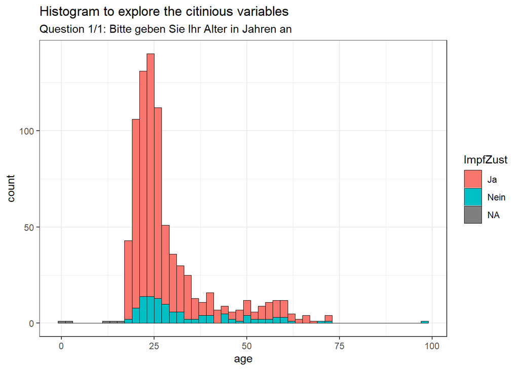

### Govtrust

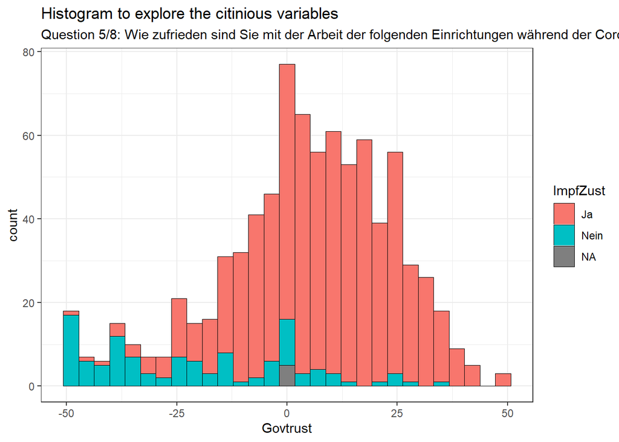

### PersoKenn

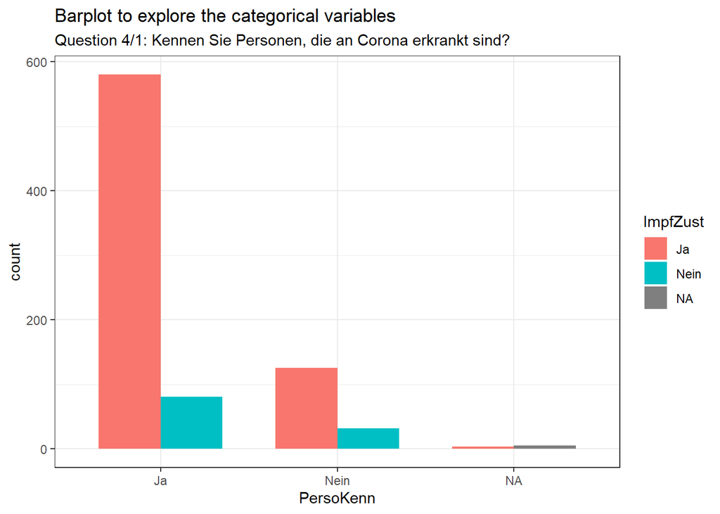

### KennErkr

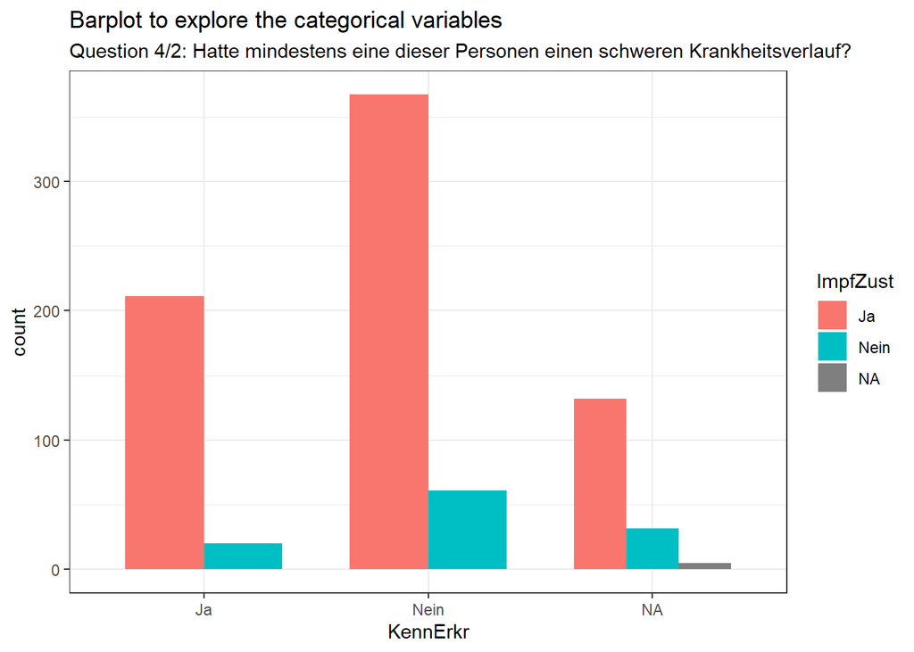

### ImpGrund[beruf]

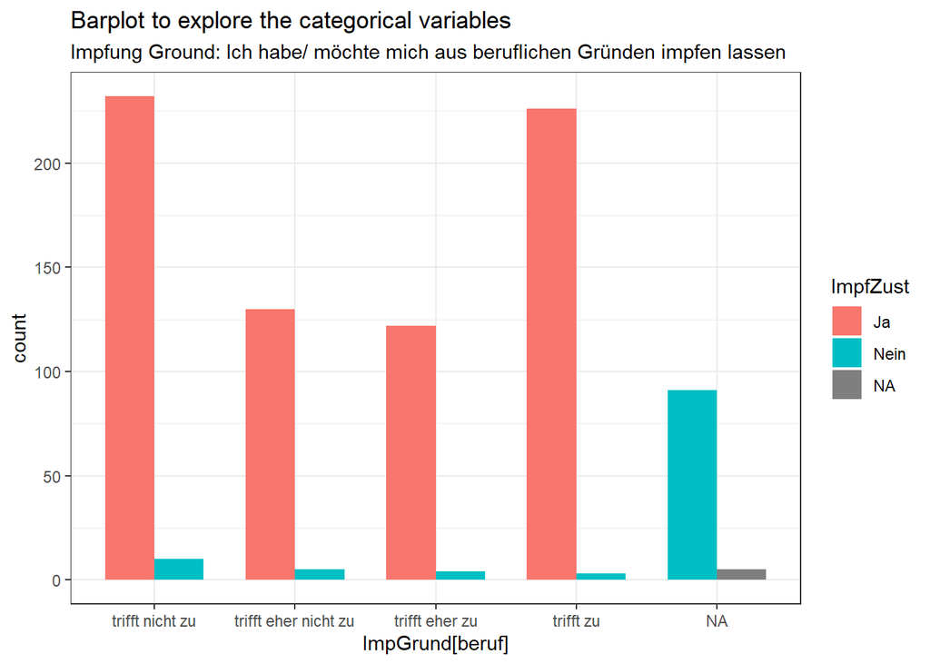

### ImpGrund[risiko]

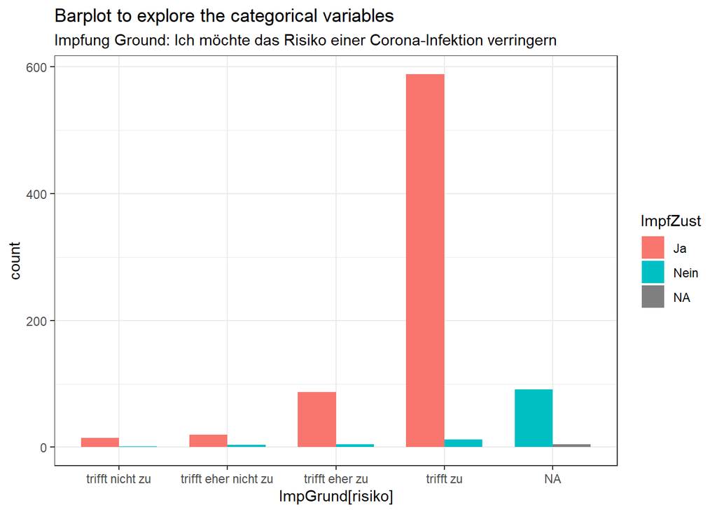

### ImpGrund[norm]

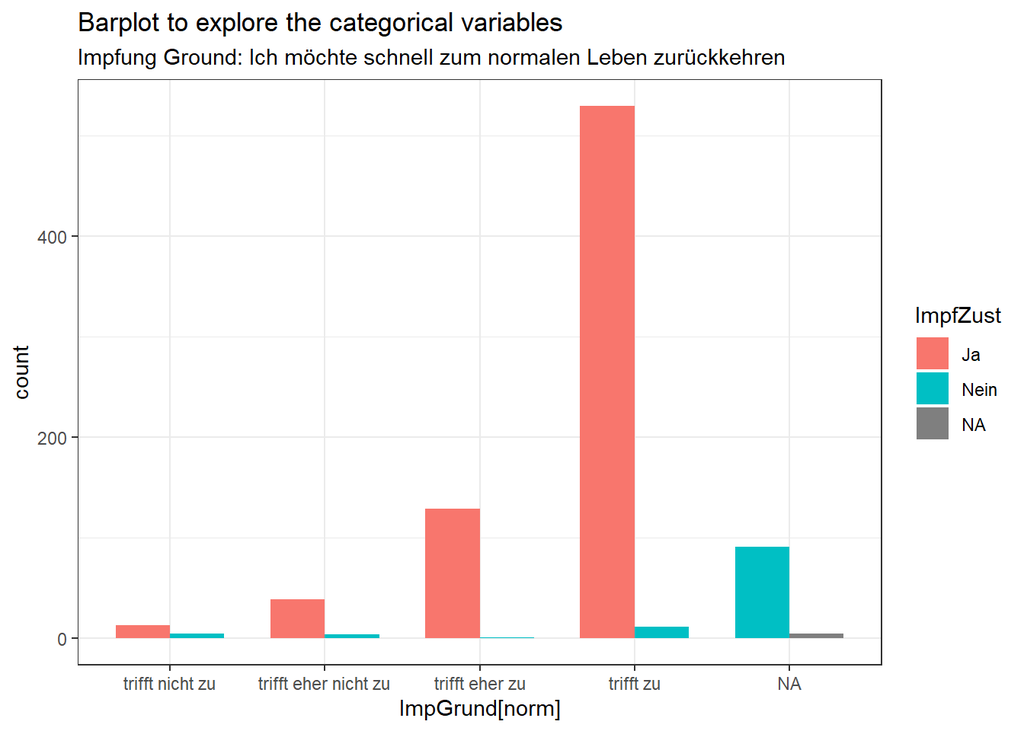

### ImpGrund[gesfam]

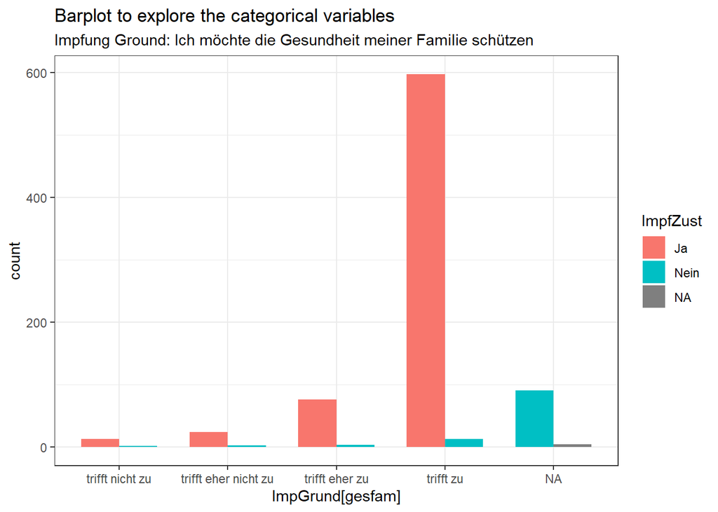

### ImpGrund[sozum]

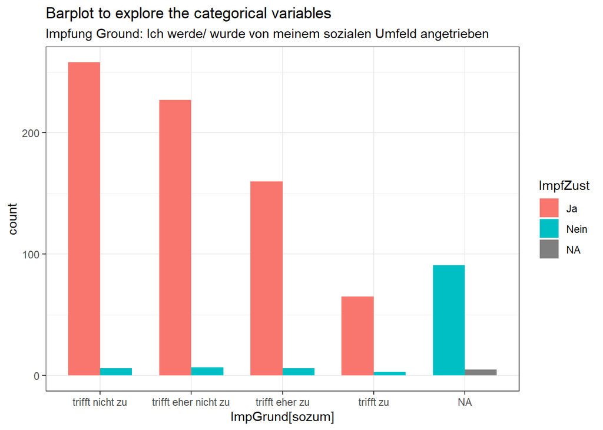

### ImpGrund[gesell]

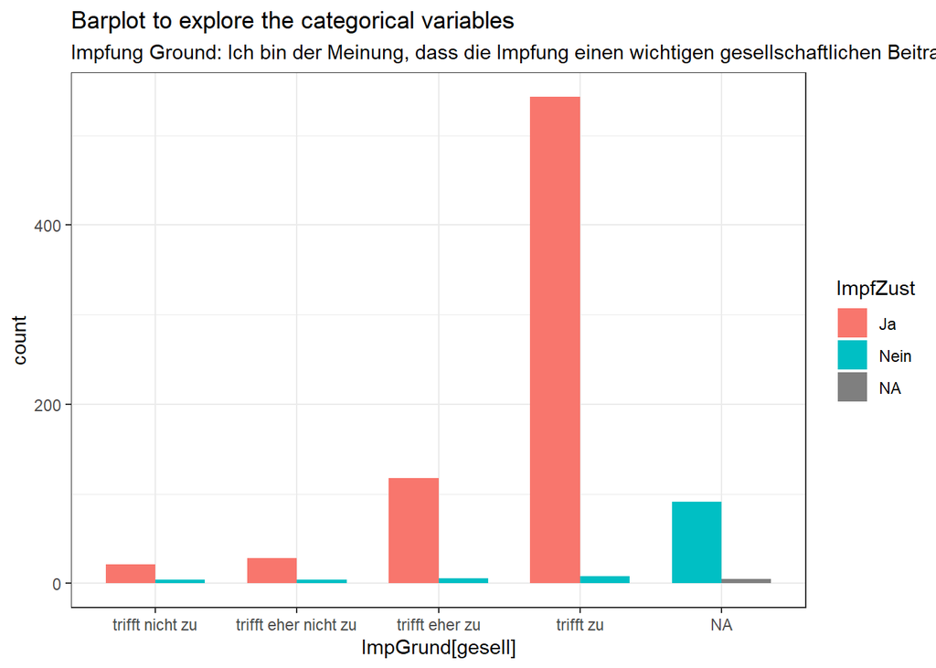

### ImpGrund[geswesent]

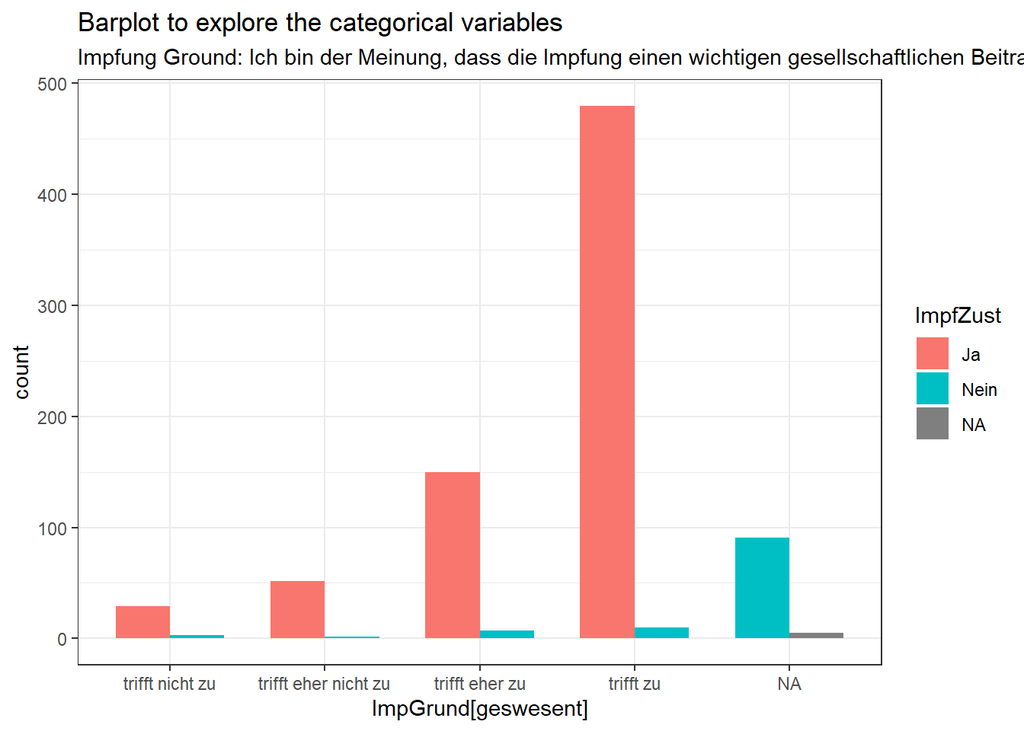

### GesuZuK

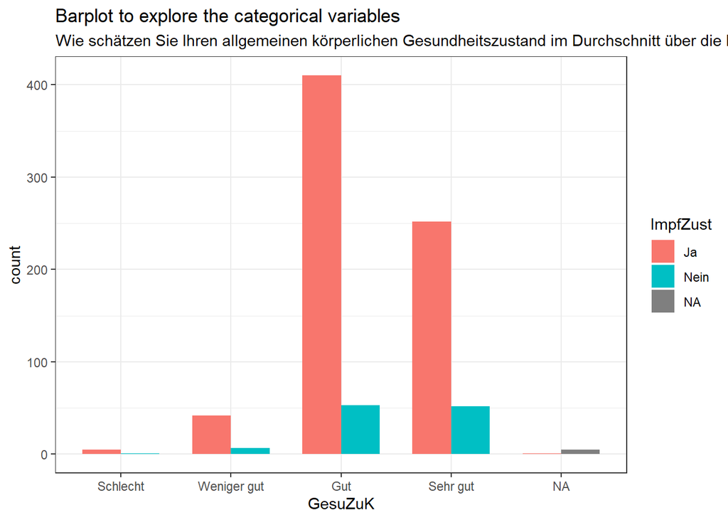

### GesuZuPsy

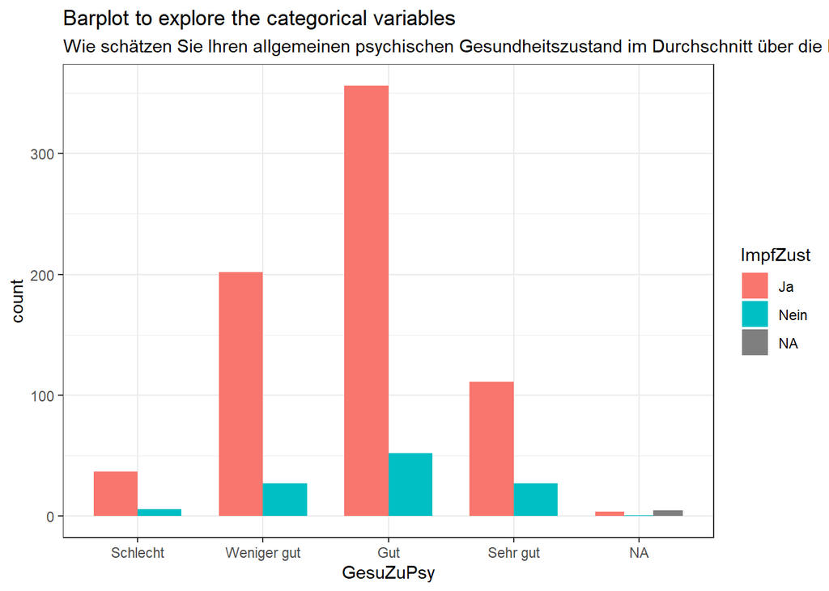

### ImpfHistory

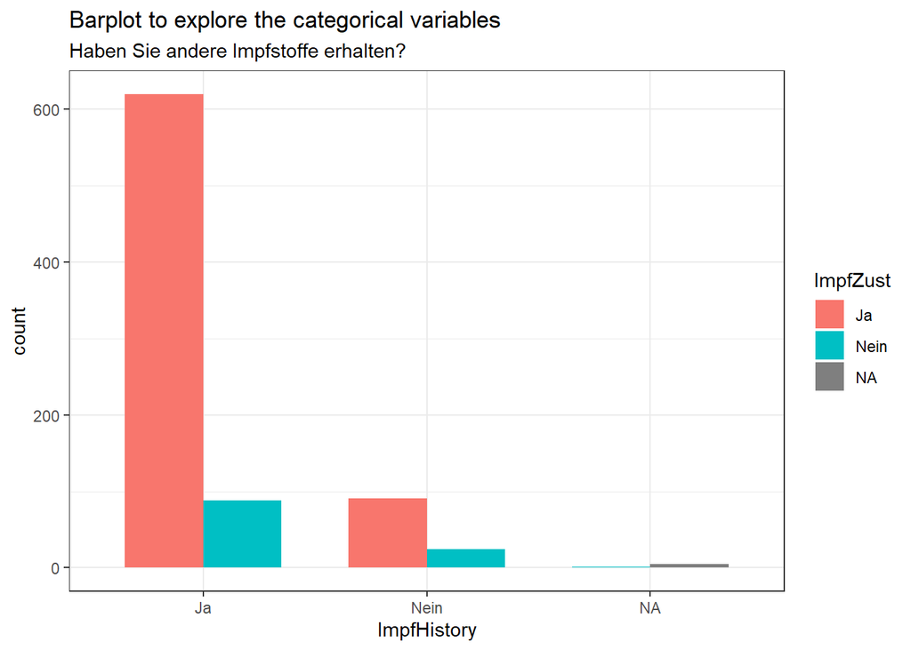

### Sex

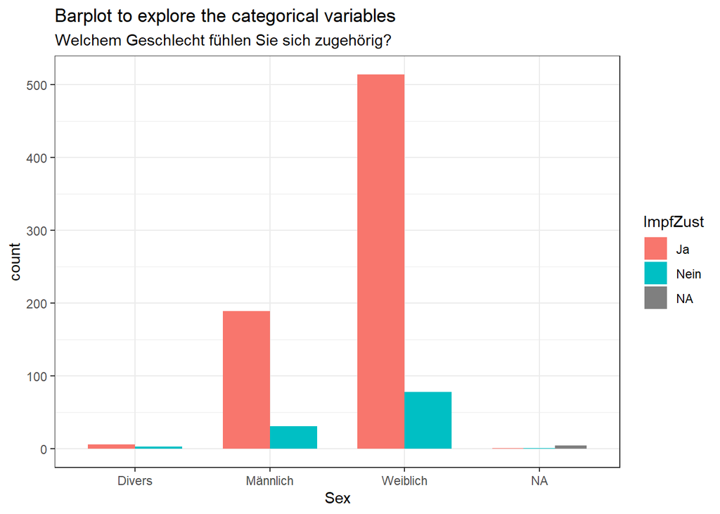

### Schulab

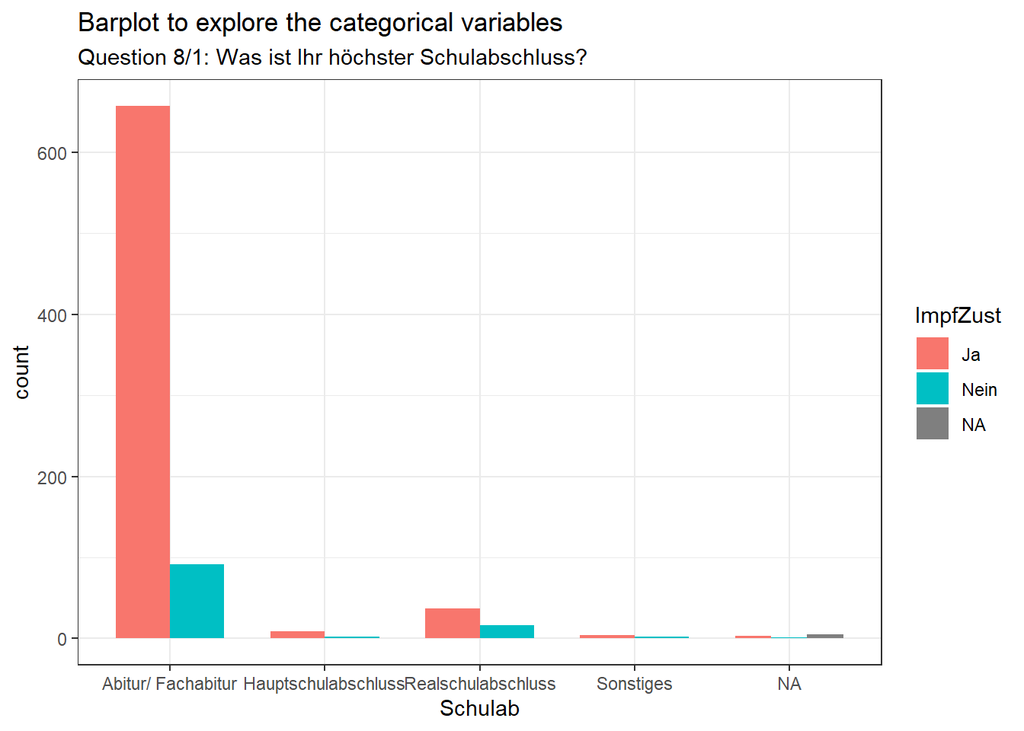

### BerufAb

[figure not shown]

### TaetGes

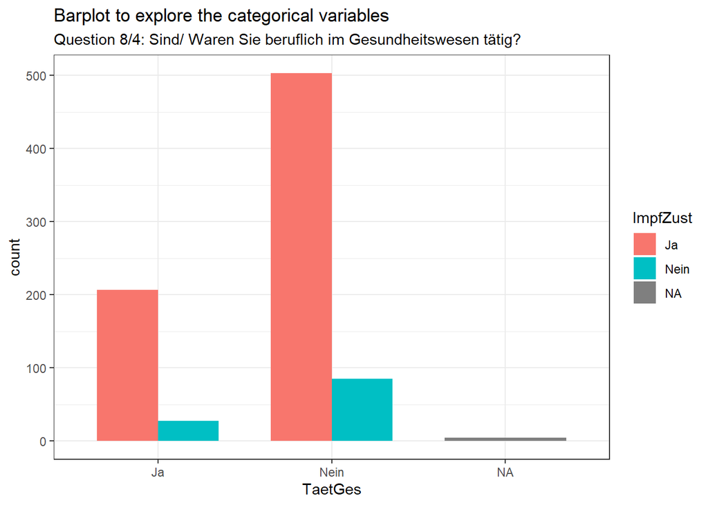

### MediWork

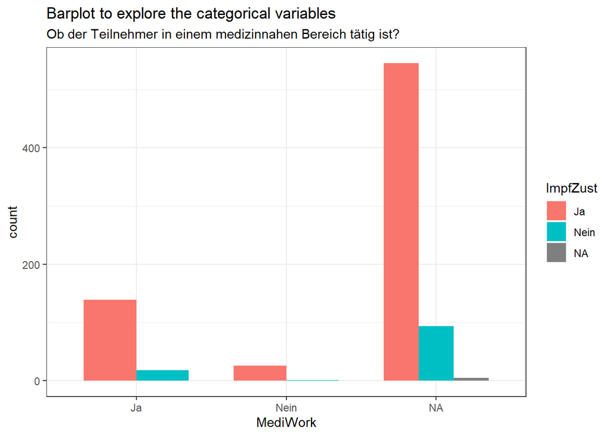

### ZeitInfo

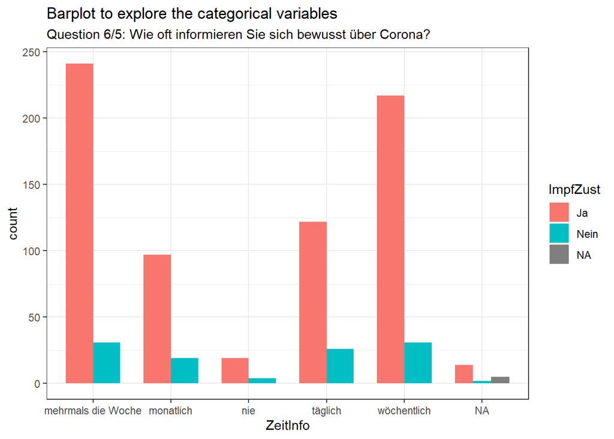

### zapaQualBe

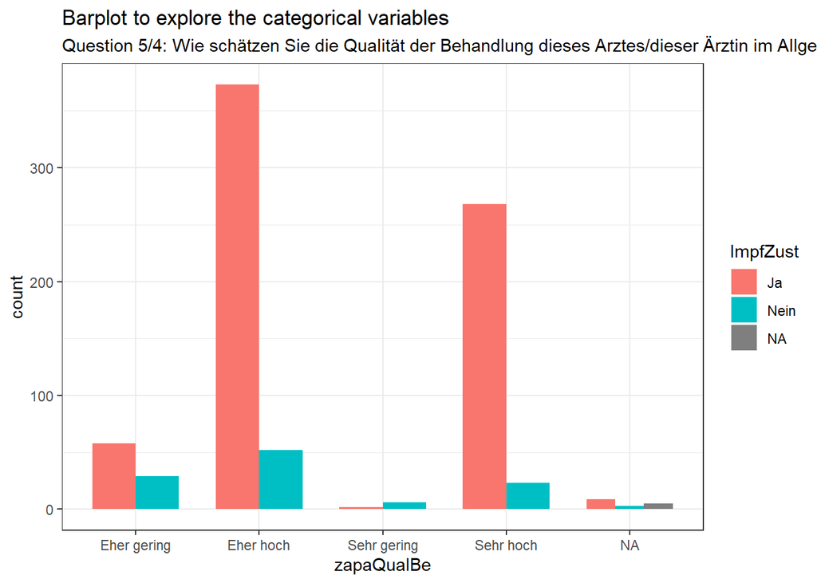

### zapaImpf

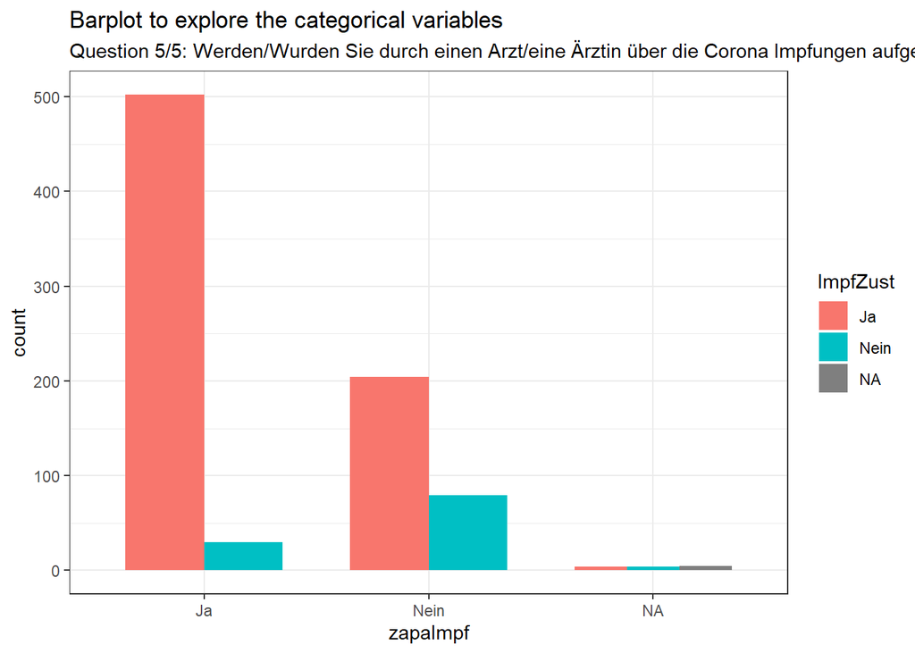

### AufklAkt

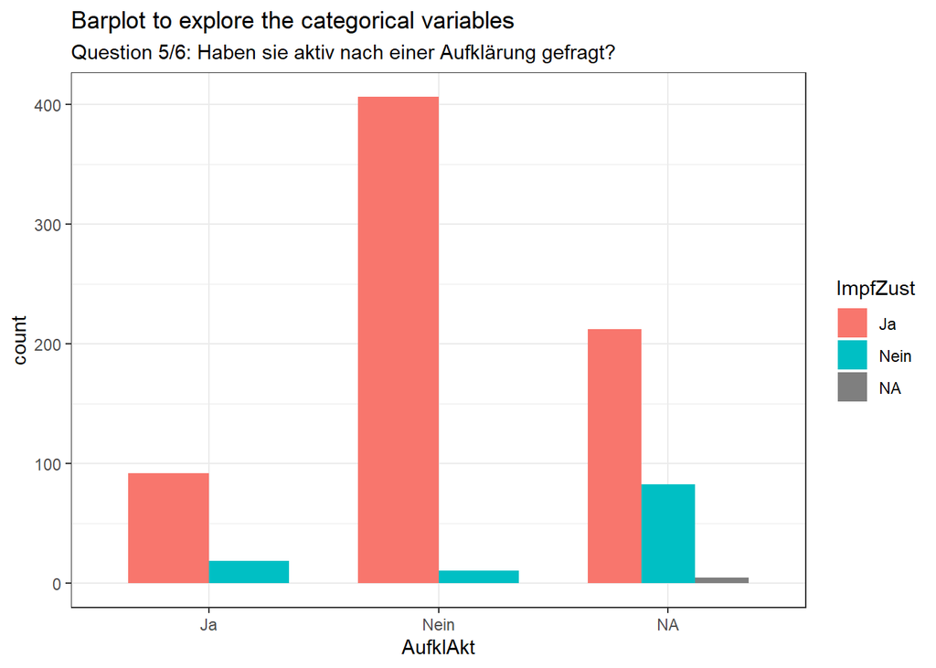

### ZufriedAufk

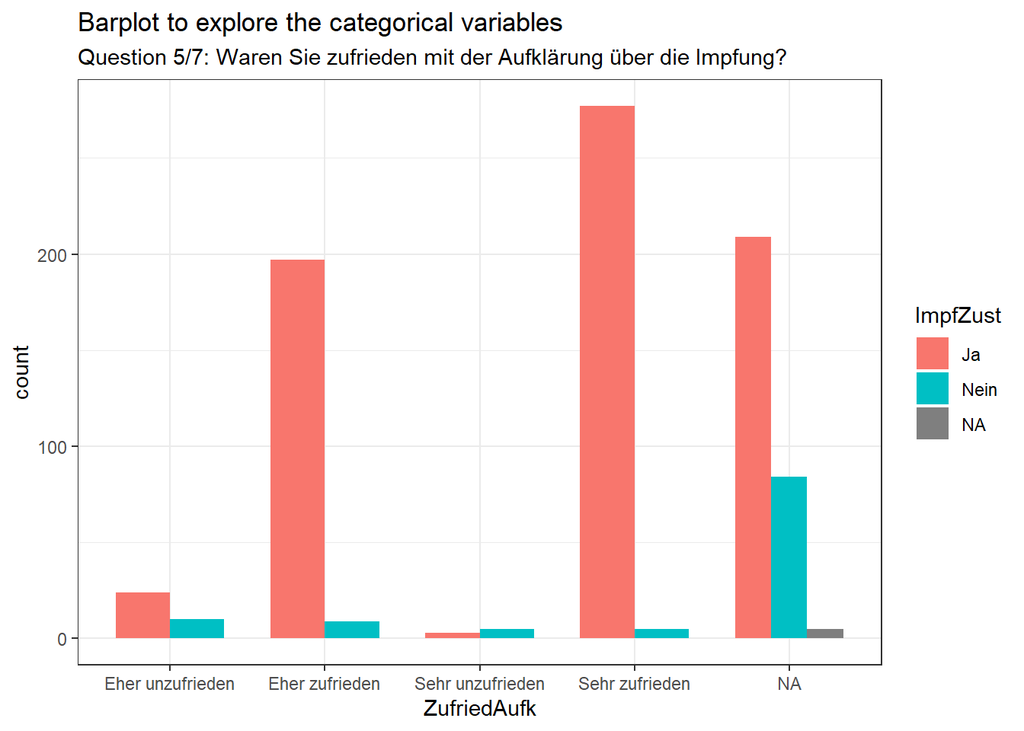

# Modeling

## Full logistic model

Following variables are included in the logistic model based on the above exploration:

- age
- Sex
- KennErkr
- Govtrust
- `ImpGrund[risiko]`
- `ImpGrund[norm]`
- GesuZuK
- Schulab
- zapaImpf
- ImpfHistory
- MediWork

Logistic results from full model

|  | ImpfZust |  |  |  |
| --- | --- | --- | --- | --- |
| Predictors | Odds Ratios | std. Error | CI | p |
| (Intercept) | 0.00 | 0.00 | 0.00 – Inf | 1.000 |
| age | 0.99 | 0.18 | 0.47 – 1.39 | 0.975 |
| Sex [Weiblich] | 48271548.80 | 1185107589181.58 | 0.00 – Inf | 0.999 |
| Govtrust | 0.93 | 0.08 | 0.75 – 1.10 | 0.449 |
| KennErkr [Nein] | 0.94 | 2.05 | 0.00 – 114.73 | 0.978 |
| ImpGrund[risiko] [ImpGrund[risiko]trifft eher nicht zu] | 0.00 | 0.00 | 0.00 – Inf | 0.999 |
| ImpGrund[risiko] [ImpGrund[risiko]trifft eher zu] | 0.00 | 0.00 | 0.00 – Inf | 1.000 |
| ImpGrund[risiko] [ImpGrund[risiko]trifft zu] | 0.00 | 0.00 | 0.00 – Inf | 1.000 |
| ImpGrund[norm] [ImpGrund[norm]trifft eher nicht zu] | 21345446798273677264068006284.00 | 1707152620489995507200006844686260.00 | 0.00 – Inf | 0.999 |
| ImpGrund[norm] [ImpGrund[norm]trifft eher zu] | 14.32 | 1162537.62 | 0.00 – Inf | 1.000 |
| ImpGrund[norm] [ImpGrund[norm]trifft zu] | 8777542956.26 | 693666770931664.12 | 0.00 – NA | 1.000 |
| GesuZuK [Gut] | 280795784.04 | 7810404945648.60 | 0.00 – NA | 0.999 |
| GesuZuK [Sehr gut] | 0.40 | 11500.65 | 0.00 – Inf | 1.000 |
| Schulab [Realschulabschluss] | 0.00 | 0.00 | NA – Inf | 1.000 |
| zapaImpf [Nein] | 6197561788551109632.00 | 76167771692878157310426.00 | 0.00 – Inf | 0.997 |
| ImpfHistory [Nein] | 0.00 | 77.10 | 0.00 – Inf | 1.000 |
| MediWork [Nein] | 2.58 | 57299.29 | 0.00 – Inf | 1.000 |
| Observations | 144 |  |  |  |
| R<sup>2</sup> Tjur | 0.497 |  |  |  |

Confidence intervall of estimates

|  | 2.5 % | 97.5 % |
| --- | --- | --- |
| (Intercept) | -1.072315e+04 | 9.444662e+03 |
| age | -7.655456e-01 | 3.295342e-01 |
| SexWeiblich | -1.421741e+03 | 1.335074e+03 |
| Govtrust | -2.905799e-01 | 9.743290e-02 |
| KennErkrNein | -5.331052e+00 | 4.742616e+00 |
| `ImpGrund[risiko]`trifft eher nicht zu | -9.716359e+03 | 8.895105e+03 |
| `ImpGrund[risiko]`trifft eher zu | -9.926504e+03 | 1.035667e+04 |
| `ImpGrund[risiko]`trifft zu | -9.215000e+03 | 9.098186e+03 |
| `ImpGrund[norm]`trifft eher nicht zu | -6.127590e+03 | 5.936006e+03 |
| `ImpGrund[norm]`trifft eher zu | -6.845546e+03 | 6.850870e+03 |
| `ImpGrund[norm]`trifft zu | -1.050186e+04 | NA |
| GesuZuKGut | -4.487668e+03 | NA |
| GesuZuKSehr gut | -1.781454e+03 | 1.847335e+03 |
| SchulabRealschulabschluss | NA | 7.314119e+03 |
| zapaImpfNein | -7.935996e+02 | 8.801410e+02 |
| ImpfHistoryNein | -4.355185e+03 | 4.580438e+03 |
| MediWorkNein | -1.513866e+03 | 1.515758e+03 |

variance inflation factor (VIF)

|  | GVIF | Df | GVIF^(1/(2*Df)) |
| --- | --- | --- | --- |
| age | 1.372222e+00 | 1 | 1.171419 |
| Sex | 1.332930e+00 | 1 | 1.154526 |
| Govtrust | 3.118498e+00 | 1 | 1.765927 |
| KennErkr | 1.747814e+00 | 1 | 1.322049 |
| `ImpGrund[risiko]` | 4.848785e+00 | 3 | 1.300985 |
| `ImpGrund[norm]` | 5.573062e+07 | 3 | 19.544099 |
| GesuZuK | 1.698587e+00 | 2 | 1.141621 |
| Schulab | 1.000000e+00 | 1 | 1.000000 |
| zapaImpf | 5.573063e+07 | 1 | 7465.295020 |
| ImpfHistory | 1.207367e+00 | 1 | 1.098803 |
| MediWork | 1.124723e+00 | 1 | 1.060529 |

**Conclusion**: as seen, the model is overfitted

## Sub model:

### Intro

Remove high collinearity factor based on variance inflation factor (VIF)

The variance inflation factor (VIF) is a measure of the severity of multiple collinearity in a multiple linear regression model, remove the variabele `ImpGrund[norm]` from the full model

`Sex` `ImpGrund[risiko]` has high SD and will be removed

Model: `ImpfZust ~ age + Govtrust+KennErkr+zapaImpf`

### Result and Plot

Logistic results from sub model

|  | ImpfZust |  |  |  |
| --- | --- | --- | --- | --- |
| Predictors | Odds Ratios | std. Error | CI | p |
| (Intercept) | 0.01 | 0.01 | 0.01 – 0.04 | **<0.001** |
| age | 1.03 | 0.01 | 1.00 – 1.05 | **0.035** |
| Govtrust | 0.93 | 0.01 | 0.91 – 0.94 | **<0.001** |
| KennErkr [Nein] | 1.35 | 0.45 | 0.71 – 2.63 | 0.368 |
| zapaImpf [Nein] | 5.86 | 1.82 | 3.23 – 10.98 | **<0.001** |
| Observations | 655 |  |  |  |
| R<sup>2</sup> Tjur | 0.368 |  |  |  |

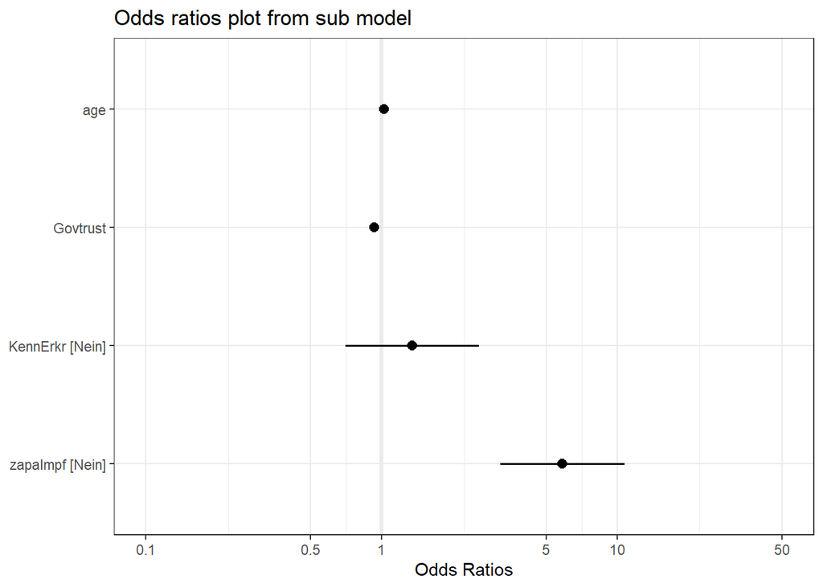

### Conclusion

**Conclusion**: as seen, the model seems nomal, `age` and `Govtrust`, `zapaImpf` have significant effect of impfung

$$\frac{\mathrm{P}\left(Impfung=Nein \right)}{\mathrm{P}\left(Impfung=Ja\right)}=\exp \left(\beta_{0}\right) \cdot \exp \left(x_{i 1} \beta_{1}\right) \cdot \ldots \cdot \exp \left(x_{i k} \beta_{k}\right)$$
* The older the age, the possibility of vaccination will be slightly reduced * The higher the trust in the government, the more likely to be vaccinated

**In the following exploration, the continuous variables `age` and `Govtrust` are retained**

## Model: Perception of disease risk

KennErkr and PersoKenn have strong correlation and cannot be placed in the model. The following two models are designed to explore the roles of KennErkr and PersoKenn separately

Models:

- `ImpfZust ~ age + Govtrust + KennErkr`
- `ImpfZust ~ age + Govtrust + PersoKenn`

Logistic results from sub model: Perception of disease risk

|  | ImpfZust |  |  |  | ImpfZust |  |  |  |
| --- | --- | --- | --- | --- | --- | --- | --- | --- |
| Predictors | Odds Ratios | std. Error | CI | p | Odds Ratios | std. Error | CI | p |
| (Intercept) | 0.03 | 0.01 | 0.01 – 0.08 | **<0.001** | 0.04 | 0.01 | 0.02 – 0.08 | **<0.001** |
| age | 1.03 | 0.01 | 1.00 – 1.05 | **0.021** | 1.03 | 0.01 | 1.01 – 1.05 | **0.005** |
| Govtrust | 0.93 | 0.01 | 0.92 – 0.94 | **<0.001** | 0.93 | 0.01 | 0.91 – 0.94 | **<0.001** |
| KennErkr [Nein] | 1.52 | 0.48 | 0.84 – 2.86 | 0.179 |  |  |  |  |
| PersoKenn [Nein] |  |  |  |  | 1.28 | 0.38 | 0.70 – 2.27 | 0.408 |
| Observations | 659 |  |  |  | 819 |  |  |  |
| R<sup>2</sup> Tjur | 0.303 |  |  |  | 0.348 |  |  |  |

## Model: Attitude towards vaccination

The following series of models are designed to explore the impact of 7 different attitudes from “Question 4/16: Warum haben/ wollen Sie sich gegen Corona impfen lassen” on vaccination.

Models:

- `ImpfZust ~ age + Govtrust + ImpGrund[beruf]`
- `ImpfZust ~ age + Govtrust + ImpGrund[risiko]`
- `ImpfZust ~ age + Govtrust + ImpGrund[norm]`
- `ImpfZust ~ age + Govtrust + ImpGrund[gesfam]`
- `ImpfZust ~ age + Govtrust + ImpGrund[sozum]`
- `ImpfZust ~ age + Govtrust + ImpGrund[gesell]`
- `ImpfZust ~ age + Govtrust + ImpGrund[geswesent]`

### ImpGrund[beruf]

Logistic results from sub model: Ich habe/ möchte mich aus beruflichen Gründen impfen lassen

|  | ImpfZust |  |  |  |
| --- | --- | --- | --- | --- |
| Predictors | Odds Ratios | std. Error | CI | p |
| (Intercept) | 0.04 | 0.03 | 0.01 – 0.17 | **<0.001** |
| age | 1.00 | 0.02 | 0.96 – 1.04 | 0.880 |
| Govtrust | 0.97 | 0.01 | 0.95 – 1.00 | **0.018** |
| ImpGrund[beruf] [ImpGrund[beruf]trifft eher nicht zu] | 0.99 | 0.56 | 0.30 – 2.89 | 0.987 |
| ImpGrund[beruf] [ImpGrund[beruf]trifft eher zu] | 0.84 | 0.51 | 0.22 – 2.61 | 0.774 |
| ImpGrund[beruf] [ImpGrund[beruf]trifft zu] | 0.33 | 0.22 | 0.07 – 1.10 | 0.096 |
| Observations | 732 |  |  |  |
| R<sup>2</sup> Tjur | 0.019 |  |  |  |

### ImpGrund[risiko]

Logistic results from sub model: Ich möchte das Risiko einer Corona-Infektion verringern

|  | ImpfZust |  |  |  |
| --- | --- | --- | --- | --- |
| Predictors | Odds Ratios | std. Error | CI | p |
| (Intercept) | 0.05 | 0.06 | 0.00 – 0.37 | **0.011** |
| age | 1.00 | 0.02 | 0.96 – 1.04 | 0.892 |
| Govtrust | 0.98 | 0.01 | 0.96 – 1.01 | 0.142 |
| ImpGrund[risiko] [ImpGrund[risiko]trifft eher nicht zu] | 3.35 | 3.95 | 0.43 – 70.01 | 0.306 |
| ImpGrund[risiko] [ImpGrund[risiko]trifft eher zu] | 1.09 | 1.25 | 0.15 – 22.09 | 0.940 |
| ImpGrund[risiko] [ImpGrund[risiko]trifft zu] | 0.46 | 0.51 | 0.07 – 9.00 | 0.483 |
| Observations | 732 |  |  |  |
| R<sup>2</sup> Tjur | 0.034 |  |  |  |

### ImpGrund[norm]

Logistic results from sub model: Ich möchte schnell zum normalen Leben zurückkehren

|  | ImpfZust |  |  |  |
| --- | --- | --- | --- | --- |
| Predictors | Odds Ratios | std. Error | CI | p |
| (Intercept) | 0.37 | 0.32 | 0.07 – 2.19 | 0.247 |
| age | 1.00 | 0.02 | 0.95 – 1.04 | 0.940 |
| Govtrust | 0.98 | 0.01 | 0.96 – 1.01 | 0.132 |
| ImpGrund[norm] [ImpGrund[norm]trifft eher nicht zu] | 0.28 | 0.21 | 0.06 – 1.26 | 0.095 |
| ImpGrund[norm] [ImpGrund[norm]trifft eher zu] | 0.02 | 0.03 | 0.00 – 0.18 | **0.001** |
| ImpGrund[norm] [ImpGrund[norm]trifft zu] | 0.07 | 0.04 | 0.02 – 0.26 | **<0.001** |
| Observations | 732 |  |  |  |
| R<sup>2</sup> Tjur | 0.073 |  |  |  |

### ImpGrund[gesfam]

Logistic results from sub model: Ich möchte die Gesundheit meiner Familie schützen

|  | ImpfZust |  |  |  |
| --- | --- | --- | --- | --- |
| Predictors | Odds Ratios | std. Error | CI | p |
| (Intercept) | 0.12 | 0.11 | 0.01 – 0.72 | **0.027** |
| age | 1.00 | 0.02 | 0.95 – 1.04 | 0.995 |
| Govtrust | 0.98 | 0.01 | 0.96 – 1.01 | 0.133 |
| ImpGrund[gesfam] [ImpGrund[gesfam]trifft eher nicht zu] | 0.91 | 0.91 | 0.13 – 7.86 | 0.926 |
| ImpGrund[gesfam] [ImpGrund[gesfam]trifft eher zu] | 0.42 | 0.40 | 0.07 – 3.40 | 0.360 |
| ImpGrund[gesfam] [ImpGrund[gesfam]trifft zu] | 0.21 | 0.18 | 0.05 – 1.53 | 0.069 |
| Observations | 732 |  |  |  |
| R<sup>2</sup> Tjur | 0.027 |  |  |  |

### ImpGrund[sozum]

Logistic results from sub model: Ich werde/ wurde von meinem sozialen Umfeld angetrieben

|  | ImpfZust |  |  |  |
| --- | --- | --- | --- | --- |
| Predictors | Odds Ratios | std. Error | CI | p |
| (Intercept) | 0.02 | 0.02 | 0.00 – 0.10 | **<0.001** |
| age | 1.01 | 0.02 | 0.96 – 1.05 | 0.717 |
| Govtrust | 0.97 | 0.01 | 0.95 – 0.99 | **0.014** |
| ImpGrund[sozum] [ImpGrund[sozum]trifft eher nicht zu] | 1.37 | 0.78 | 0.44 – 4.37 | 0.579 |
| ImpGrund[sozum] [ImpGrund[sozum]trifft eher zu] | 1.63 | 0.98 | 0.49 – 5.46 | 0.419 |
| ImpGrund[sozum] [ImpGrund[sozum]trifft zu] | 2.16 | 1.60 | 0.44 – 8.80 | 0.297 |
| Observations | 732 |  |  |  |
| R<sup>2</sup> Tjur | 0.012 |  |  |  |

### ImpGrund[gesell]

Logistic results from sub model: Ich bin der Meinung, dass die Impfung einen wichtigen gesellschaftlichen Beitrag darstellt

|  | ImpfZust |  |  |  |
| --- | --- | --- | --- | --- |
| Predictors | Odds Ratios | std. Error | CI | p |
| (Intercept) | 0.17 | 0.14 | 0.03 – 0.91 | **0.036** |
| age | 1.00 | 0.02 | 0.95 – 1.04 | 0.972 |
| Govtrust | 0.99 | 0.01 | 0.97 – 1.02 | 0.523 |
| ImpGrund[gesell] [ImpGrund[gesell]trifft eher nicht zu] | 0.78 | 0.60 | 0.16 – 3.67 | 0.743 |
| ImpGrund[gesell] [ImpGrund[gesell]trifft eher zu] | 0.30 | 0.22 | 0.08 – 1.33 | 0.093 |
| ImpGrund[gesell] [ImpGrund[gesell]trifft zu] | 0.09 | 0.07 | 0.02 – 0.42 | **0.001** |
| Observations | 732 |  |  |  |
| R<sup>2</sup> Tjur | 0.045 |  |  |  |

### ImpGrund[geswesent]

|  | ImpfZust |  |  |  |
| --- | --- | --- | --- | --- |
| Predictors | Odds Ratios | std. Error | CI | p |
| (Intercept) | 0.08 | 0.07 | 0.01 – 0.50 | **0.007** |
| age | 1.00 | 0.02 | 0.95 – 1.04 | 0.993 |
| Govtrust | 0.98 | 0.01 | 0.95 – 1.00 | 0.078 |
| ImpGrund[geswesent] [ImpGrund[geswesent]trifft eher nicht zu] | 0.47 | 0.45 | 0.06 – 3.10 | 0.434 |
| ImpGrund[geswesent] [ImpGrund[geswesent]trifft eher zu] | 0.66 | 0.51 | 0.16 – 3.46 | 0.590 |
| ImpGrund[geswesent] [ImpGrund[geswesent]trifft zu] | 0.33 | 0.25 | 0.08 – 1.70 | 0.141 |
| Observations | 732 |  |  |  |
| R<sup>2</sup> Tjur | 0.017 |  |  |  |

## Model: One’s own health status

The following series of models are designed to explore the impact of

- körperlichen Gesundheitszustand
- psychischen Gesundheitszustand
- Impfungen -geschicht

on vaccination.

Models:

- `ImpfZust ~ age + Govtrust + GesuZuK`
- `ImpfZust ~ age + Govtrust + GesuZuPsy`
- `ImpfZust ~ age + Govtrust + ImpfHistory`

### GesuZuKGesuZuK

Logistic results from sub model: Wie schätzen Sie Ihren allgemeinen körperlichen Gesundheitszustand im Durchschnitt über die letzten sechs Monate ein?

|  | ImpfZust |  |  |  |
| --- | --- | --- | --- | --- |
| Predictors | Odds Ratios | std. Error | CI | p |
| (Intercept) | 0.03 | 0.04 | 0.00 – 0.33 | **0.010** |
| age | 1.03 | 0.01 | 1.01 – 1.06 | **0.001** |
| Govtrust | 0.93 | 0.01 | 0.91 – 0.94 | **<0.001** |
| GesuZuK [Weniger gut] | 1.06 | 1.49 | 0.09 – 28.77 | 0.966 |
| GesuZuK [Gut] | 0.94 | 1.26 | 0.09 – 23.53 | 0.965 |
| GesuZuK [Sehr gut] | 1.97 | 2.64 | 0.18 – 49.64 | 0.613 |
| Observations | 822 |  |  |  |
| R<sup>2</sup> Tjur | 0.362 |  |  |  |

### GesuZuPsy

Logistic results from sub model: Wie schätzen Sie Ihren allgemeinen psychischen Gesundheitszustand im Durchschnitt über die letzten sechs Monate ein?

|  | ImpfZust |  |  |  |
| --- | --- | --- | --- | --- |
| Predictors | Odds Ratios | std. Error | CI | p |
| (Intercept) | 0.02 | 0.02 | 0.01 – 0.08 | **<0.001** |
| age | 1.03 | 0.01 | 1.01 – 1.05 | **0.006** |
| Govtrust | 0.93 | 0.01 | 0.91 – 0.94 | **<0.001** |
| GesuZuPsy [Weniger gut] | 1.30 | 0.75 | 0.45 – 4.37 | 0.648 |
| GesuZuPsy [Gut] | 1.79 | 0.99 | 0.65 – 5.81 | 0.295 |
| GesuZuPsy [Sehr gut] | 2.56 | 1.52 | 0.85 – 8.91 | 0.113 |
| Observations | 818 |  |  |  |
| R<sup>2</sup> Tjur | 0.359 |  |  |  |

### ImpfHistory

Logistic results from sub model: Haben Sie impfungen bereits erhalten?

|  | ImpfZust |  |  |  |
| --- | --- | --- | --- | --- |
| Predictors | Odds Ratios | std. Error | CI | p |
| (Intercept) | 0.04 | 0.01 | 0.02 – 0.08 | **<0.001** |
| age | 1.03 | 0.01 | 1.01 – 1.05 | **0.009** |
| Govtrust | 0.93 | 0.01 | 0.91 – 0.94 | **<0.001** |
| ImpfHistory [Nein] | 2.07 | 0.66 | 1.10 – 3.83 | **0.022** |
| Observations | 822 |  |  |  |
| R<sup>2</sup> Tjur | 0.353 |  |  |  |

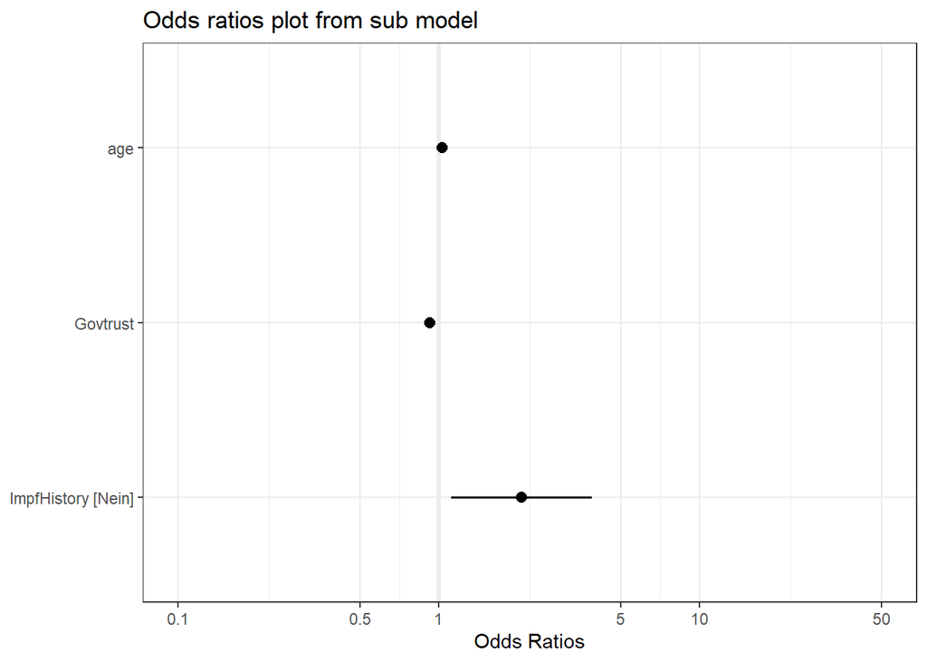

**Conclusion**: People who have previously received other vaccines are more likely to get COVID vaccine

## Model: Socio-economic status

The following series of models are designed to explore the impact of

- höchster Schulabschluss
- höchster beruflicher Abschluss
- beruflich im Gesundheitswesen tätig
- Medizinisches Bereich tätig

on vaccination.

Models:

- `ImpfZust ~ age + Govtrust + Schulab`
- `ImpfZust ~ age + Govtrust + BerufAb`
- `ImpfZust ~ age + Govtrust + TaetGes`
- `ImpfZust ~ age + Govtrust + MediWork`

### Schulab

Logistic results from sub model: Was ist Ihr höchster Schulabschluss

|  | ImpfZust |  |  |  |
| --- | --- | --- | --- | --- |
| Predictors | Odds Ratios | std. Error | CI | p |
| (Intercept) | 0.04 | 0.01 | 0.02 – 0.08 | **<0.001** |
| age | 1.03 | 0.01 | 1.01 – 1.05 | **0.009** |
| Govtrust | 0.93 | 0.01 | 0.91 – 0.94 | **<0.001** |
| Schulab [Hauptschulabschluss] | 0.29 | 0.29 | 0.03 – 1.78 | 0.212 |
| Schulab [Realschulabschluss] | 1.26 | 0.56 | 0.52 – 2.97 | 0.605 |
| Schulab [Sonstiges] | 1.47 | 1.98 | 0.07 – 16.01 | 0.775 |
| Observations | 819 |  |  |  |
| R<sup>2</sup> Tjur | 0.357 |  |  |  |

### BerufAb

Logistic results from sub model: Was ist Ihr höchster beruflicher Abschluss

|  | ImpfZust |  |  |  |
| --- | --- | --- | --- | --- |
| Predictors | Odds Ratios | std. Error | CI | p |
| (Intercept) | 0.05 | 0.02 | 0.02 – 0.10 | **<0.001** |
| age | 1.02 | 0.01 | 1.00 – 1.04 | 0.091 |
| Govtrust | 0.92 | 0.01 | 0.91 – 0.94 | **<0.001** |
| BerufAb [Beruflich-betriebliche Ausbildung] | 1.88 | 0.59 | 1.02 – 3.47 | **0.042** |
| BerufAb [Hochschulabschluss (Promotion, Habilitation)] | 4.69 | 2.79 | 1.40 – 14.67 | **0.009** |
| BerufAb [Keinen beruflichen Abschluss] | 0.74 | 0.28 | 0.34 – 1.52 | 0.415 |
| BerufAb [Sonstiges] | 0.21 | 0.23 | 0.02 – 1.50 | 0.144 |
| BerufAb [Staatsexamen] | 1.35 | 0.82 | 0.38 – 4.20 | 0.625 |
| Observations | 813 |  |  |  |
| R<sup>2</sup> Tjur | 0.378 |  |  |  |

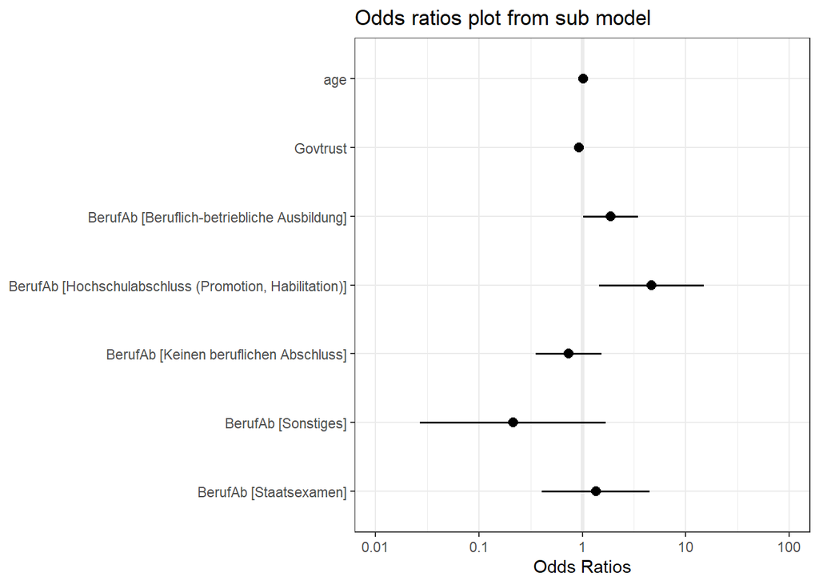

### TaetGes

Logistic results from sub model: Sind/ Waren Sie beruflich im Gesundheitswesen tätig?

|  | ImpfZust |  |  |  |
| --- | --- | --- | --- | --- |
| Predictors | Odds Ratios | std. Error | CI | p |
| (Intercept) | 0.03 | 0.01 | 0.01 – 0.07 | **<0.001** |
| age | 1.03 | 0.01 | 1.01 – 1.05 | **0.003** |
| Govtrust | 0.93 | 0.01 | 0.91 – 0.94 | **<0.001** |
| TaetGes [Nein] | 1.34 | 0.38 | 0.78 – 2.36 | 0.299 |
| Observations | 823 |  |  |  |
| R<sup>2</sup> Tjur | 0.348 |  |  |  |

### MediWork

Logistic results from sub model: Sind/ Waren Sie im medizinischen Bereich tätig

|  | ImpfZust |  |  |  |
| --- | --- | --- | --- | --- |
| Predictors | Odds Ratios | std. Error | CI | p |
| (Intercept) | 0.03 | 0.03 | 0.00 – 0.18 | **<0.001** |
| age | 1.03 | 0.03 | 0.98 – 1.09 | 0.251 |
| Govtrust | 0.91 | 0.02 | 0.87 – 0.94 | **<0.001** |
| MediWork [Nein] | 0.48 | 0.54 | 0.02 – 3.13 | 0.511 |
| Observations | 184 |  |  |  |
| R<sup>2</sup> Tjur | 0.350 |  |  |  |

## Model: Access to health information

Model: `ImpfZust ~ age + Govtrust + ZeitInfo`

Logistic results from sub model: Wie oft informieren Sie sich bewusst über Corona?

|  | ImpfZust |  |  |  |
| --- | --- | --- | --- | --- |
| Predictors | Odds Ratios | std. Error | CI | p |
| (Intercept) | 0.04 | 0.02 | 0.02 – 0.10 | **<0.001** |
| age | 1.03 | 0.01 | 1.01 – 1.05 | **0.008** |
| Govtrust | 0.93 | 0.01 | 0.91 – 0.94 | **<0.001** |
| ZeitInfo [monatlich] | 1.12 | 0.43 | 0.52 – 2.36 | 0.761 |
| ZeitInfo [nie] | 0.56 | 0.41 | 0.11 – 2.07 | 0.431 |
| ZeitInfo [täglich] | 1.29 | 0.47 | 0.63 – 2.62 | 0.482 |
| ZeitInfo [wöchentlich] | 0.72 | 0.24 | 0.37 – 1.39 | 0.328 |
| Observations | 807 |  |  |  |
| R<sup>2</sup> Tjur | 0.363 |  |  |  |

## Compliance with health professionals

Models:

- `ImpfZust ~ age + Govtrust + zapaQualBe`
- `ImpfZust ~ age + Govtrust + zapaImpf`
- `ImpfZust ~ age + Govtrust + AufklAkt`
- `ImpfZust ~ age + Govtrust + ZufriedAufk`

### zapaQualBe

Logistic results from sub model: Wie schätzen Sie die Qualität der Behandlung dieses Arztes/dieser Ärztin im Allgemeinen ein?

|  | ImpfZust |  |  |  |
| --- | --- | --- | --- | --- |
| Predictors | Odds Ratios | std. Error | CI | p |
| (Intercept) | 0.10 | 0.04 | 0.04 – 0.23 | **<0.001** |
| age | 1.03 | 0.01 | 1.01 – 1.05 | **0.009** |
| Govtrust | 0.93 | 0.01 | 0.91 – 0.94 | **<0.001** |
| zapaQualBe [Eher hoch] | 0.44 | 0.15 | 0.23 – 0.87 | **0.016** |
| zapaQualBe [Sehr gering] | 1.32 | 1.48 | 0.16 – 14.72 | 0.807 |
| zapaQualBe [Sehr hoch] | 0.23 | 0.09 | 0.11 – 0.49 | **<0.001** |
| Observations | 811 |  |  |  |
| R<sup>2</sup> Tjur | 0.368 |  |  |  |

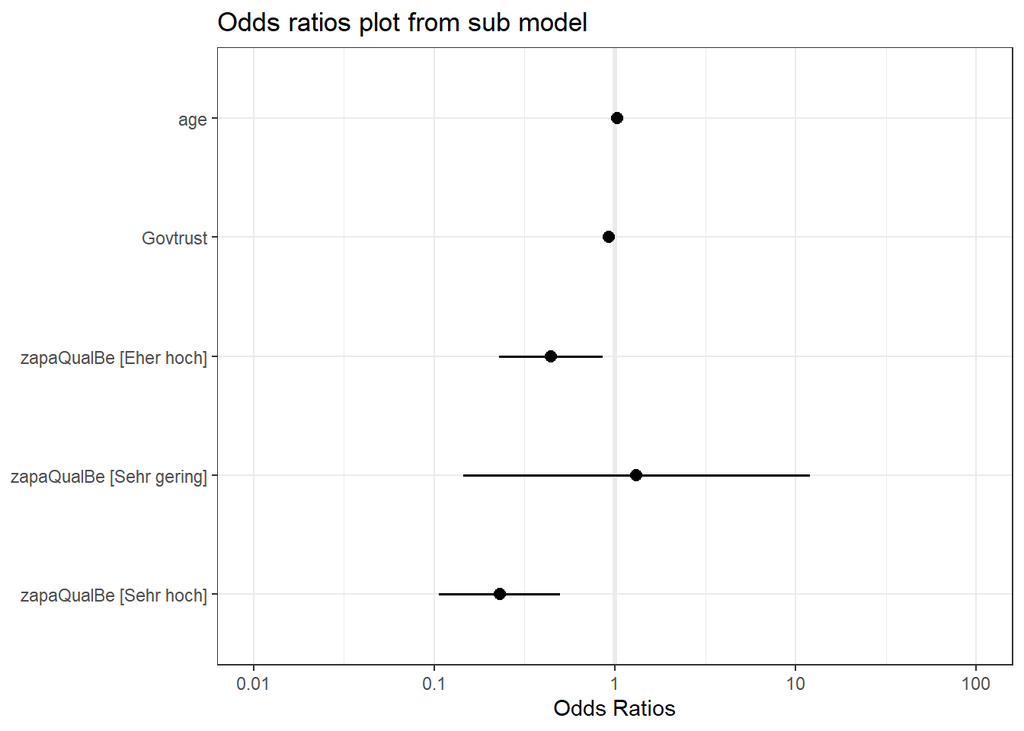

### zapaImpf

Logistic results from sub model: Werden/Wurden Sie durch einen Arzt/eine Ärztin über die Corona Impfungen aufgeklärt?

|  | ImpfZust |  |  |  |
| --- | --- | --- | --- | --- |
| Predictors | Odds Ratios | std. Error | CI | p |
| (Intercept) | 0.02 | 0.01 | 0.01 – 0.04 | **<0.001** |
| age | 1.03 | 0.01 | 1.01 – 1.05 | **0.007** |
| Govtrust | 0.93 | 0.01 | 0.92 – 0.94 | **<0.001** |
| zapaImpf [Nein] | 5.25 | 1.43 | 3.11 – 9.08 | **<0.001** |
| Observations | 815 |  |  |  |
| R<sup>2</sup> Tjur | 0.404 |  |  |  |

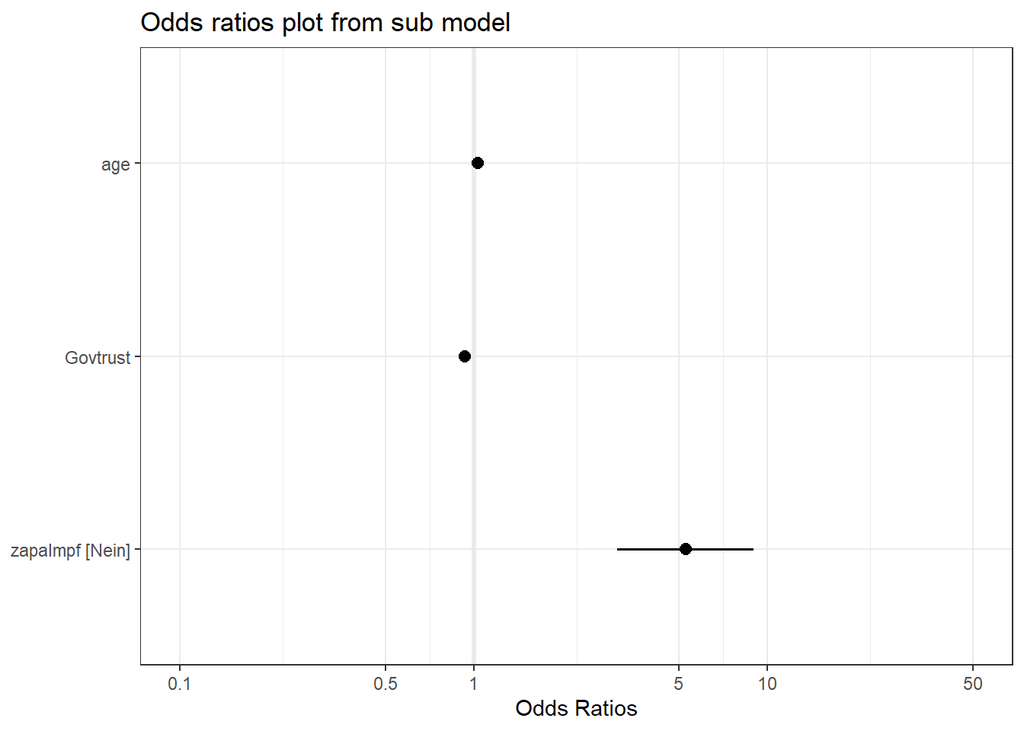

### AufklAkt

Logistic results from sub model: Haben sie aktiv nach einer Aufklärung gefragt?

|  | ImpfZust |  |  |  |
| --- | --- | --- | --- | --- |
| Predictors | Odds Ratios | std. Error | CI | p |
| (Intercept) | 0.07 | 0.05 | 0.02 – 0.25 | **<0.001** |
| age | 1.02 | 0.02 | 0.99 – 1.06 | 0.186 |
| Govtrust | 0.94 | 0.01 | 0.91 – 0.96 | **<0.001** |
| AufklAkt [Nein] | 0.18 | 0.08 | 0.07 – 0.42 | **<0.001** |
| Observations | 528 |  |  |  |
| R<sup>2</sup> Tjur | 0.286 |  |  |  |

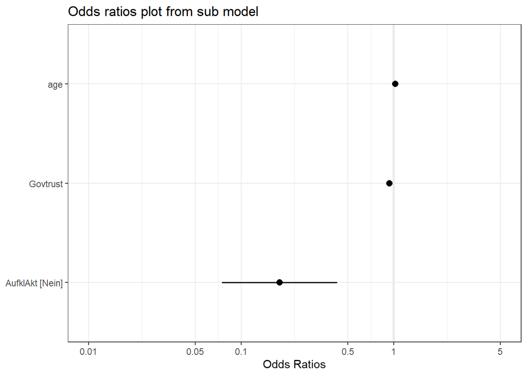

### ZufriedAufk

Logistic results from sub model: Waren Sie zufrieden mit der Aufklärung über die Impfung

|  | ImpfZust |  |  |  |
| --- | --- | --- | --- | --- |
| Predictors | Odds Ratios | std. Error | CI | p |
| (Intercept) | 0.07 | 0.05 | 0.02 – 0.28 | **<0.001** |
| age | 1.04 | 0.02 | 1.00 – 1.07 | **0.040** |
| Govtrust | 0.94 | 0.01 | 0.92 – 0.97 | **<0.001** |
| ZufriedAufk [Eher zufrieden] | 0.18 | 0.10 | 0.06 – 0.57 | **0.003** |
| ZufriedAufk [Sehr unzufrieden] | 2.41 | 2.35 | 0.37 – 17.71 | 0.365 |
| ZufriedAufk [Sehr zufrieden] | 0.09 | 0.06 | 0.02 – 0.30 | **<0.001** |
| Observations | 530 |  |  |  |
| R<sup>2</sup> Tjur | 0.304 |  |  |  |

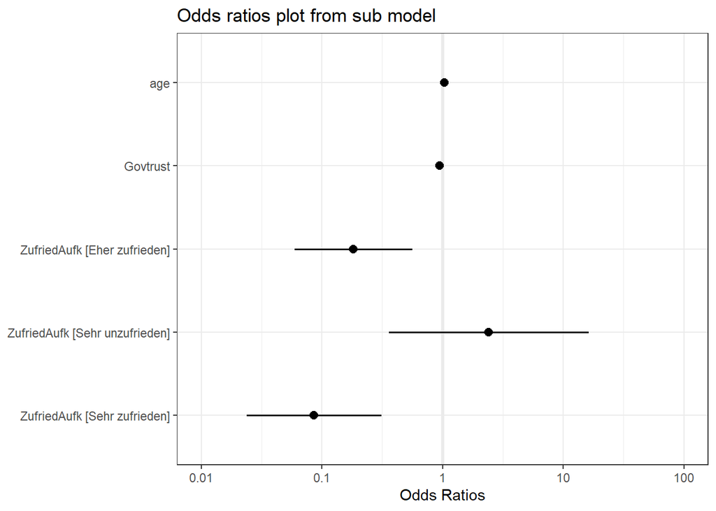

**Conclusion**: factors of Compliance with health professionals are important to vaccination.

# Additional analysis

## ImpDos question 4/5

- Descriptive analysis result has shown above, following displays the barplot

[figure not shown]

## Socio-demographic data sex

- If diverse is not considered, sex will be summarized in the following table

|  | geimpft | nicht geimpft | Total | geimpfte proportion |
| --- | --- | --- | --- | --- |
| Männlich | 189 | 31 | 220 | 85.9% |
| Weiblich | 514 | 78 | 592 | 86.8% |

- Conduct two-proportions z-test

$H_0: p_A = p_B$ v.s. $H_0: p_A \ne p_B$ and the test statistic is
$$z = \frac{p_A-p_B}{\sqrt{pq/n_A+pq/n_B}}$$

The test result p-value = 0.8226, no difference was observed

```
##
##  2-sample test for equality of proportions with continuity correction
##
## data:  c(189, 514) out of c(220, 592)
## X-squared = 0.050266, df = 1, p-value = 0.8226
## alternative hypothesis: two.sided
## 95 percent confidence interval:
##  -0.06571174  0.04740707
## sample estimates:
##    prop 1    prop 2
## 0.8590909 0.8682432
```

## 8/1 Schulab Abitur

Convert this variable into a binar variable, and conduct a proportion test

|  | geimpft | nicht geimpft | Total | geimpfte proportion |
| --- | --- | --- | --- | --- |
| Abiturabschluss | 657 | 92 | 749 | 87.7% |
| Nicht Abiturabschluss | 50 | 20 | 70 | 71.4% |

The result is significant, which means the Abiturabschluss may be inclined to vaccination, and it can be put into the model in the next step. In order to avoid confusion, the model does not add other variables and only pays attention to the influence of Abitur

```
##
##  2-sample test for equality of proportions with continuity correction
##
## data:  c(657, 50) out of c(749, 70)
## X-squared = 13.041, df = 1, p-value = 0.0003048
## alternative hypothesis: two.sided
## 95 percent confidence interval:
##  0.04666596 0.27910173
## sample estimates:
##    prop 1    prop 2
## 0.8771696 0.7142857
```

Logistic results from sub model: ImpfZust ~ Schulab

|  | ImpfZust |  |  |  |
| --- | --- | --- | --- | --- |
| Predictors | Odds Ratios | std. Error | CI | p |
| (Intercept) | 0.14 | 0.02 | 0.11 – 0.17 | **<0.001** |
| Schulab [Hauptschulabschluss] | 1.59 | 1.25 | 0.24 – 6.28 | 0.559 |
| Schulab [Realschulabschluss] | 3.09 | 0.99 | 1.61 – 5.68 | **<0.001** |
| Schulab [Sonstiges] | 3.57 | 3.12 | 0.49 – 18.56 | 0.145 |
| Observations | 819 |  |  |  |
| R<sup>2</sup> Tjur | 0.019 |  |  |  |

Logistic results from sub model: ImpfZust ~ Abitur

|  | ImpfZust |  |  |  |
| --- | --- | --- | --- | --- |
| Predictors | Odds Ratios | std. Error | CI | p |
| (Intercept) | 0.14 | 0.02 | 0.11 – 0.17 | **<0.001** |
| Abitur [Nein] | 2.86 | 0.82 | 1.60 – 4.95 | **<0.001** |
| Observations | 819 |  |  |  |
| R<sup>2</sup> Tjur | 0.018 |  |  |  |

## 8/3 Nicht erwerbstätig

there are 12 categories, and some categories of da have no significant meaning, so I will use the first variable to make an analysis for the working and non-working people

|  | geimpft | nicht geimpft | Total | geimpfte proportion |
| --- | --- | --- | --- | --- |
| erwerbstätig | 656 | 105 | 761 | 86.2% |
| Nicht erwerbstätig | 54 | 8 | 62 | 87.1% |

```
##
##  2-sample test for equality of proportions with continuity correction
##
## data:  c(656, 54) out of c(761, 62)
## X-squared = 2.397e-05, df = 1, p-value = 0.9961
## alternative hypothesis: two.sided
## 95 percent confidence interval:
##  -0.10463418  0.08674601
## sample estimates:
##    prop 1    prop 2
## 0.8620237 0.8709677
```

## 9/5 Aleine Leben

As shown above table “PersHausAlone”

[output not shown]

```
##
##  2-sample test for equality of proportions with continuity correction
##
## data:  c(142, 556) out of c(167, 638)
## X-squared = 0.34754, df = 1, p-value = 0.5555
## alternative hypothesis: two.sided
## 95 percent confidence interval:
##  -0.08497196  0.04262405
## sample estimates:
##    prop 1    prop 2
## 0.8502994 0.8714734
```

## 6/2 Instagram and Twitter

based on the above table fuhter analysis

immer and oft can be combined as haufig nutzen, andere als gar selten

### InfoInt[Inst] Instagram

|  | geimpft | nicht geimpft | Total | geimpfte proportion |
| --- | --- | --- | --- | --- |
| Nutzen Instagram häufig | 234 | 26 | 260 | 90.0% |
| Nutzen Instagram gar selten | 471 | 65 | 536 | 87.9% |

```
##
##  2-sample test for equality of proportions with continuity correction
##
## data:  c(234, 471) out of c(260, 536)
## X-squared = 0.58622, df = 1, p-value = 0.4439
## alternative hypothesis: two.sided
## 95 percent confidence interval:
##  -0.02734159  0.06987890
## sample estimates:
##    prop 1    prop 2
## 0.9000000 0.8787313
```

### InfoInt[Twitt] Twitter

|  | geimpft | nicht geimpft | Total | geimpfte proportion |
| --- | --- | --- | --- | --- |
| Nutzen Twitter häufig | 75 | 4 | 79 | 94.9% |
| Nutzen ITwitter gar selten | 630 | 107 | 737 | 85.5% |

```
##
##  2-sample test for equality of proportions with continuity correction
##
## data:  c(75, 630) out of c(79, 737)
## X-squared = 4.6528, df = 1, p-value = 0.031
## alternative hypothesis: two.sided
## 95 percent confidence interval:
##  0.03291408 0.15618644
## sample estimates:
##    prop 1    prop 2
## 0.9493671 0.8548168
```

## 6/4 Informationsaustausch

### Informationsaustausch mit Familienmitgliedern/Freunden

| Informationsaustausch mit Familienmitgliedern/Freunden | geimpft | nicht geimpft | Total | geimpfte proportion |
| --- | --- | --- | --- | --- |
| Nie | 5 | 4 | 9 | 55.6% |
| täglich | 156 | 31 | 187 | 83.4% |
| wöchentlich | 134 | 24 | 158 | 84.8% |
| mehrmals die Woche and monatlich | 411 | 52 | 463 | 88.8% |

Alternative tabulate

| Informationsaustausch mit Familienmitgliedern/Freunden | geimpft | nicht geimpft | Total | geimpfte proportion |
| --- | --- | --- | --- | --- |
| Nie | 5 | 4 | 9 | 55.6% |
| Ja (täglich, wöchentlich, …) | 701 | 107 | 808 | 86.8% |

```
##
##  2-sample test for equality of proportions with continuity correction
##
## data:  c(5, 701) out of c(9, 808)
## X-squared = 4.9625, df = 1, p-value = 0.0259
## alternative hypothesis: two.sided
## 95 percent confidence interval:
##  -0.69367123  0.06963382
## sample estimates:
##    prop 1    prop 2
## 0.5555556 0.8675743
```

```
##
##  Fisher's Exact Test for Count Data
##
## data:  matrix(c(5, 4, 701, 107), 2, 2)
## p-value = 0.02359
## alternative hypothesis: true odds ratio is not equal to 1
## 95 percent confidence interval:
##  0.04050367 0.98036246
## sample estimates:
## odds ratio
##  0.1914234
```

### Informationsaustausch mit Fachleuten

| Informationsaustausch mit Fachleuten | geimpft | nicht geimpft | Total | geimpfte proportion |
| --- | --- | --- | --- | --- |
| Nie | 282 | 33 | 315 | 89.5% |
| Ja (täglich, wöchentlich, …) | 423 | 74 | 497 | 85.1% |

```
##
##  2-sample test for equality of proportions with continuity correction
##
## data:  c(282, 423) out of c(315, 497)
## X-squared = 2.9077, df = 1, p-value = 0.08816
## alternative hypothesis: two.sided
## 95 percent confidence interval:
##  -0.004540388  0.092803298
## sample estimates:
##    prop 1    prop 2
## 0.8952381 0.8511066
```

## 6/5 ZeitInfo

**Wie oft informieren Sie sich bewusst über Corona?**

[output not shown]

```
##
##  2-sample test for equality of proportions with continuity correction
##
## data:  c(19, 677) out of c(23, 784)
## X-squared = 0.042701, df = 1, p-value = 0.8363
## alternative hypothesis: two.sided
## 95 percent confidence interval:
##  -0.2165674  0.1417005
## sample estimates:
##    prop 1    prop 2
## 0.8260870 0.8635204
```

## 9/6 Wie hoch ist Ihr monatliches Nettoeinkommen

See results above, futher categories can be showed as:

| Nettoeinkommen | geimpft | nicht geimpft | Total | geimpfte proportion |
| --- | --- | --- | --- | --- |
| Unter 1.000€ | 365 | 40 | 405 | 90.1% |
| 1.000€-2.000€ | 173 | 32 | 205 | 84.4% |
| 2.000€-4.000€ | 124 | 23 | 147 | 84.4% |
| Mehr als 4.000€ | 25 | 11 | 36 | 69.4% |

```
##
##  4-sample test for equality of proportions without continuity
##  correction
##
## data:  c(365, 173, 124, 25) out of c(405, 205, 147, 36)
## X-squared = 14.996, df = 3, p-value = 0.00182
## alternative hypothesis: two.sided
## sample estimates:
##    prop 1    prop 2    prop 3    prop 4
## 0.9012346 0.8439024 0.8435374 0.6944444
```